# CSE5DEV - Assignment 2

2024-09-07

Student ID : 22114129  
Student Name: Sandip Subedi

Get your current working directory in R using **getwd ()** function

```r
dir=getwd()
```

Set your working directory in R using **setwd ()** function

```r
setwd(dir)
```

```r
#DO NOT CHANGE THE CODE BELOW!
word_count <- function(s)
  {
    return(length(strsplit(str, "\\s+")[[1]]))
  }
```

## Task 1

[ChatGPT url](https://chatgpt.com/share/67032791-1d7c-8012-bf31-0cc5cdfbeb64)

**Valid link**

Task 1.a

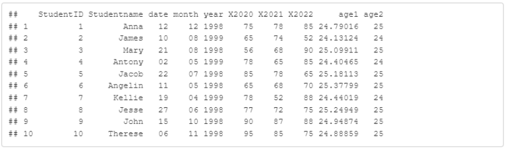

R code to produce the correct dataframe

```r
# load CSV into  data frame called df
df <- read.csv("Studentmarks.csv")

# Checking the structure of the dataframe df
str(df)
```

```
## 'data.frame':    10 obs. of  6 variables:
##  $ StudentID  : int  1 2 3 4 5 6 7 8 9 10
##  $ Studentname: chr  "Anna" "James" "Mary" "Antony" ...
##  $ dob        : chr  "12/12/1998" "10/08/1999" "21/08/1998" "02/05/1999" ...
##  $ X2020      : int  75 65 56 78 85 65 78 77 90 95
##  $ X2021      : int  78 74 68 65 78 68 52 72 87 85
##  $ X2022      : int  85 52 90 85 65 70 88 75 88 75
```

```r
# Converting the dob column into a date object
df$dob <- as.Date(df$dob, format = "%d/%m/%Y")

# Checking the structure of the dataframe again to confirm the conversion
str(df)
```

```
## 'data.frame':    10 obs. of  6 variables:
##  $ StudentID  : int  1 2 3 4 5 6 7 8 9 10
##  $ Studentname: chr  "Anna" "James" "Mary" "Antony" ...
##  $ dob        : Date, format: "1998-12-12" "1999-08-10" ...
##  $ X2020      : int  75 65 56 78 85 65 78 77 90 95
##  $ X2021      : int  78 74 68 65 78 68 52 72 87 85
##  $ X2022      : int  85 52 90 85 65 70 88 75 88 75
```

```r
# Calculate the current age from the dob column and store it in a new column 'age1'
df$age1 <- round(as.numeric(difftime(Sys.Date(), df$dob, units = "days")) / 365.25, 5)

# View the updated dataframe
head(df)
```

```
##   StudentID Studentname        dob X2020 X2021 X2022     age1
## 1         1        Anna 1998-12-12    75    78    85 25.83984
## 2         2       James 1999-08-10    65    74    52 25.18001
## 3         3        Mary 1998-08-21    56    68    90 26.14921
## 4         4      Antony 1999-05-02    78    65    85 25.45380
## 5         5       Jacob 1998-07-22    85    78    65 26.23135
## 6         6     Angelin 1998-05-11    65    68    70 26.42847
```

```r
# Extract day, month, and year from the dob column into separate columns
df$day <- as.integer(format(df$dob, "%d"))  # Extract day
df$month <- as.integer(format(df$dob, "%m"))  # Extract month
df$year <- as.integer(format(df$dob, "%Y"))  # Extract year

# View the updated dataframe
head(df)
```

```
##   StudentID Studentname        dob X2020 X2021 X2022     age1 day month year
## 1         1        Anna 1998-12-12    75    78    85 25.83984  12    12 1998
## 2         2       James 1999-08-10    65    74    52 25.18001  10     8 1999
## 3         3        Mary 1998-08-21    56    68    90 26.14921  21     8 1998
## 4         4      Antony 1999-05-02    78    65    85 25.45380   2     5 1999
## 5         5       Jacob 1998-07-22    85    78    65 26.23135  22     7 1998
## 6         6     Angelin 1998-05-11    65    68    70 26.42847  11     5 1998
```

```r
#Extracting the current year
current_year <- as.integer(format(Sys.Date(), "%Y"))

#Calculate age using year only and store it in a new column 'age2'
df$age2 <- current_year - df$year

#updated dataframe
print(df)
```

```
##    StudentID Studentname        dob X2020 X2021 X2022     age1 day month year
## 1          1        Anna 1998-12-12    75    78    85 25.83984  12    12 1998
## 2          2       James 1999-08-10    65    74    52 25.18001  10     8 1999
## 3          3        Mary 1998-08-21    56    68    90 26.14921  21     8 1998
## 4          4      Antony 1999-05-02    78    65    85 25.45380   2     5 1999
## 5          5       Jacob 1998-07-22    85    78    65 26.23135  22     7 1998
## 6          6     Angelin 1998-05-11    65    68    70 26.42847  11     5 1998
## 7          7      Kellie 1999-04-19    78    52    88 25.48939  19     4 1999
## 8          8       Jesse 1998-06-27    77    72    75 26.29979  27     6 1998
## 9          9        John 1998-10-15    90    87    88 25.99863  15    10 1998
## 10        10     Therese 1998-11-06    95    85    75 25.93840   6    11 1998
##    age2
## 1    26
## 2    25
## 3    26
## 4    25
## 5    26
## 6    26
## 7    25
## 8    26
## 9    26
## 10   26
```

```r
#drop dob column
df$dob <- NULL

#view updated df
print(df)
```

```
##    StudentID Studentname X2020 X2021 X2022     age1 day month year age2
## 1          1        Anna    75    78    85 25.83984  12    12 1998   26
## 2          2       James    65    74    52 25.18001  10     8 1999   25
## 3          3        Mary    56    68    90 26.14921  21     8 1998   26
## 4          4      Antony    78    65    85 25.45380   2     5 1999   25
## 5          5       Jacob    85    78    65 26.23135  22     7 1998   26
## 6          6     Angelin    65    68    70 26.42847  11     5 1998   26
## 7          7      Kellie    78    52    88 25.48939  19     4 1999   25
## 8          8       Jesse    77    72    75 26.29979  27     6 1998   26
## 9          9        John    90    87    88 25.99863  15    10 1998   26
## 10        10     Therese    95    85    75 25.93840   6    11 1998   26
```

```r
#change name of column 'day'to 'date'
colnames(df)[which(names(df) == "day")] <- "date"

#view updated df
print(df)
```

```
##    StudentID Studentname X2020 X2021 X2022     age1 date month year age2
## 1          1        Anna    75    78    85 25.83984   12    12 1998   26
## 2          2       James    65    74    52 25.18001   10     8 1999   25
## 3          3        Mary    56    68    90 26.14921   21     8 1998   26
## 4          4      Antony    78    65    85 25.45380    2     5 1999   25
## 5          5       Jacob    85    78    65 26.23135   22     7 1998   26
## 6          6     Angelin    65    68    70 26.42847   11     5 1998   26
## 7          7      Kellie    78    52    88 25.48939   19     4 1999   25
## 8          8       Jesse    77    72    75 26.29979   27     6 1998   26
## 9          9        John    90    87    88 25.99863   15    10 1998   26
## 10        10     Therese    95    85    75 25.93840    6    11 1998   26
```

```r
#reordering the columns
df <- df[, c("StudentID","Studentname","date","month","year","X2020","X2021","X2022","age1","age2")]

#view updated df
print(df)
```

```
##    StudentID Studentname date month year X2020 X2021 X2022     age1 age2
## 1          1        Anna   12    12 1998    75    78    85 25.83984   26
## 2          2       James   10     8 1999    65    74    52 25.18001   25
## 3          3        Mary   21     8 1998    56    68    90 26.14921   26
## 4          4      Antony    2     5 1999    78    65    85 25.45380   25
## 5          5       Jacob   22     7 1998    85    78    65 26.23135   26
## 6          6     Angelin   11     5 1998    65    68    70 26.42847   26
## 7          7      Kellie   19     4 1999    78    52    88 25.48939   25
## 8          8       Jesse   27     6 1998    77    72    75 26.29979   26
## 9          9        John   15    10 1998    90    87    88 25.99863   26
## 10        10     Therese    6    11 1998    95    85    75 25.93840   26
```

Task 1.a: My own words to explain how the code works.

```r
str<-" I imported a CSV file containing student marks into a dataframe named df. Since the dob column was initially in character format, I converted it to the date data type and calculated each student's age based on their date of birth. To find the age, l used the difftime function to determine the difference in days between the current date ( Sys. Date () ) and the dob. The calculated age is stored in a new column called age1. Additionally, I extracted the current year from Sys.Date() to compute age2, representing the age in years only.I removed the dob column from the dataframe.To rename the day column to date, I used the colnames function, and finally, I specified the order of the columns using the c() function to ensure they are arranged as desired."
print(paste("Word Count: ",word_count(str)))
```

```
## [1] "Word Count:  135"
```

Task 1.b

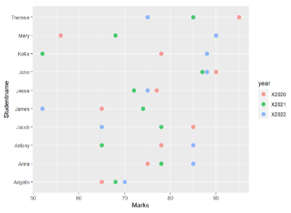

R code to produce the correct chart here

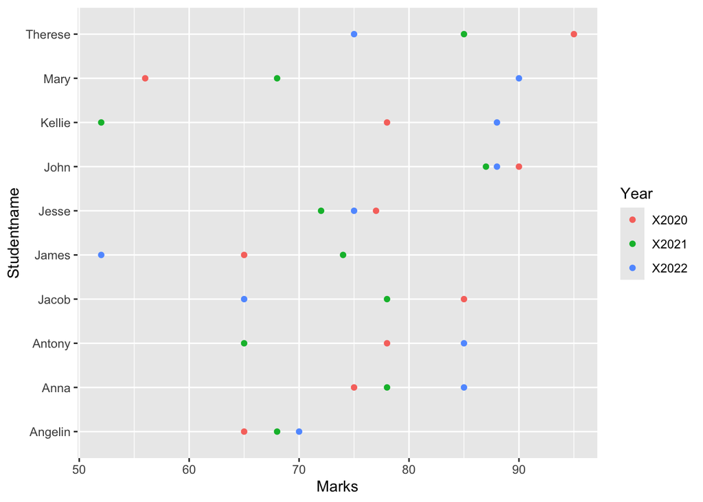

```r
# Loading ggplot2 library for plotting
library(ggplot2)

#Create scatter plot with labels and color legend title
ggplot(df) +
  geom_point(aes(x = X2020, y = Studentname, color = "X2020")) +
  geom_point(aes(x = X2021, y = Studentname, color = "X2021")) +
  geom_point(aes(x = X2022, y = Studentname, color = "X2022")) +
  labs(x = "Marks", y = "Studentname", color = "Year")
```

Task 1.b : My own words to explain how the code works.

```r
str<-"I am using the ggplot library to make a scatter plot. The geom_point function adds points to the plot based on the values from different columns. Here, I use geom_point three times to show data for the years X2020, X2021, and X2022, each in a different color for easy identification."
print(paste("Word Count: ",word_count(str)))
```

```
## [1] "Word Count:  50"
```

Task 1.c

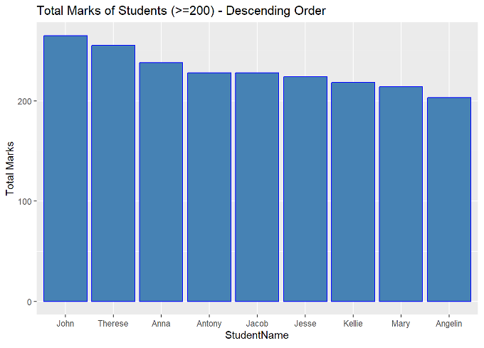

R code to produce the correct chart here

```r
#library used for data manipulation and transformation like filter and mutate
library(dplyr)
```

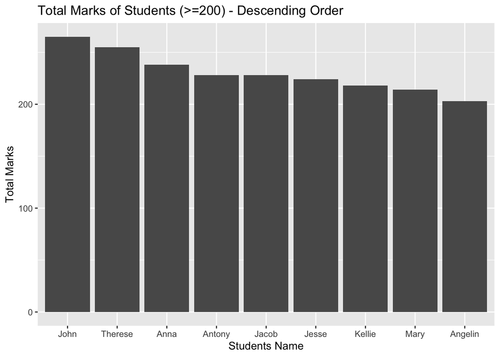

```r
df %>%
  mutate(total_marks = X2020 + X2021 + X2022) %>% #mutate function for creating a column
  filter(total_marks >= 200) %>% #filter function to filter data and store in a same column
  ggplot(aes(x = reorder(Studentname, -total_marks), y = total_marks)) +
  geom_bar(stat = "identity") + #height of barchart with actual number
  labs(x = "Students Name", y = "Total Marks", title = "Total Marks of Students (>=200) - Descending Order")
```

Task 1.c: My own words to explain how the code works.

```r
#Use your own words to explain how the code works for 1.c
str<-"First marks from columns X2020, X2021 and X2022 is added into a new column called total_marks using the mutate function in dataframe called df. Filter function filters the data from total_column with value greater or equal to 200. Then geom_bar is used to produced bar diagram. reorder function reordes the Studentname variable based on values of totalmarks(descending) indidicated by negative sign.labs function is used for correct labeling of axis and title.  "
print(paste("Word Count: ",word_count(str)))
```

```
## [1] "Word Count:  71"
```

## Task 2

Task 2.a Loading dataset and observe rows and column

```r
#loading dirty_iris.csv data
dirty_iris <- read.csv("dirty_iris.csv", header=TRUE)
dirty_iris
```

```
##     Sepal.Length Sepal.Width Petal.Length Petal.Width    Species
## 1            5.1         3.5          1.4         0.2     setosa
## 2            4.9         3.0          1.4         0.2     setosa
## 3            4.7         3.2          1.3         0.2     setosa
## 4            4.6         3.1          1.5         0.2     setosa
## 5            5.0         3.6          1.4         0.2     setosa
## 6            5.4         3.9          1.7         0.4     setosa
## 7            4.6         3.4          1.4         0.3     setosa
## 8            5.0         3.4          1.5         0.2     setosa
## 9            4.4         2.9          1.4         0.2     setosa
## 10           4.9         3.1          1.5         0.1     setosa
## 11           5.4         3.7          1.5         0.2     setosa
## 12           4.8         3.4          1.6         0.2     setosa
## 13           4.8         3.0          1.4         0.1     setosa
## 14           4.3         3.0          1.1         0.1
```

[output cut: 136 more lines]

```r
#gives the dimension of the dataset
dim(dirty_iris)
```

```
## [1] 150   5
```

```r
#Print  Missing Values details
sapply(dirty_iris, function(x) sum(is.na(x)))
```

```
## Sepal.Length  Sepal.Width Petal.Length  Petal.Width      Species
##            0            0           12            0            0
```

```r
# sapply() applies the sum function to each column in the dataframe to count empty strings
empty_strings <- sapply(dirty_iris, function(x) sum(x == "", na.rm = TRUE))
empty_strings
```

```
## Sepal.Length  Sepal.Width Petal.Length  Petal.Width      Species
##            0            0            0            0            3
```

```r
# Replacing all empty strings in the Species column with NA
dirty_iris$Species[dirty_iris$Species == ""] <- NA

#Checking again if empty strings exists or not
sum(dirty_iris$Species== "", na.rm=TRUE)
```

```
## [1] 0
```

```r
#Checking number of NAs again
sapply(dirty_iris, function(x) sum(is.na(x)))
```

```
## Sepal.Length  Sepal.Width Petal.Length  Petal.Width      Species
##            0            0           12            0            3
```

```r
#displaying data types of the columns
sapply(dirty_iris, class)
```

```
## Sepal.Length  Sepal.Width Petal.Length  Petal.Width      Species
##    "numeric"    "numeric"    "numeric"    "numeric"  "character"
```

```r
#Displaying statistical information about the dataset
summary(dirty_iris)
```

```
##   Sepal.Length    Sepal.Width     Petal.Length    Petal.Width
##  Min.   :4.300   Min.   :2.000   Min.   :1.000   Min.   :0.100
##  1st Qu.:5.100   1st Qu.:2.800   1st Qu.:1.525   1st Qu.:0.300
##  Median :5.800   Median :3.000   Median :4.350   Median :1.300
##  Mean   :5.843   Mean   :3.057   Mean   :3.775   Mean   :1.199
##  3rd Qu.:6.400   3rd Qu.:3.300   3rd Qu.:5.100   3rd Qu.:1.800
##  Max.   :7.900   Max.   :4.400   Max.   :6.900   Max.   :2.500
##                                  NA's   :12
##    Species
##  Length:150
##  Class :character
##  Mode  :character
##
##
##
##
```

```r
# colMeans() function returns the ratio of NAs for each column
print(colMeans(is.na(dirty_iris))*100 )
```

```
## Sepal.Length  Sepal.Width Petal.Length  Petal.Width      Species
##            0            0            8            0            2
```

Observing histogram, mean and median to decide the imputation on missing values

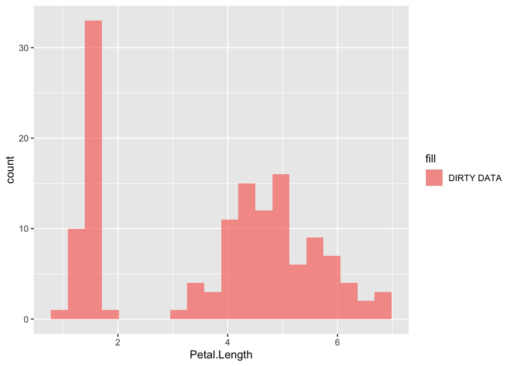

```r
ggplot() + # function for plotting any graph using ggplot2 library
  geom_histogram(data=dirty_iris, aes(x = Petal.Length, fill = "DIRTY DATA"), #creates histogram
                 bins = 20, alpha = 0.7, na.rm=TRUE)
```

```r
# mean and median function
print(mean(dirty_iris$Petal.Length, na.rm=TRUE))
```

```
## [1] 3.775362
```

```r
print(median(dirty_iris$Petal.Length, na.rm=TRUE))
```

```
## [1] 4.35
```

Task 2.a: My explanation

```r
str<-"I plan to replace the missing values in the Petal.Length column with the median because the data isn't normally distributed. The histograms show that Petal.Length is skewed to the left, which makes the mean shift in that direction. The median, however, stays near the center of the data and isn't as affected by the skew. "

print(paste("Word Count: ",word_count(str)))
```

```
## [1] "Word Count:  55"
```

Task 2.b Implementing Median Imputation

```r
#Put your Code here
#Finding the indices of missing values(NA) in Petal.Length and Species feature
ind1 <- which(is.na(dirty_iris$Petal.Length))
ind1
```

```
##  [1]  25  27  46  47  48  66  88  96 121 122 138 145
```

```r
#Copying data frame to new name 'dat'
dat <- dirty_iris

#Replace Missing values in Sepal.Length by median value
#ind1 is the indices of missing values of Petal.length
media<- median(dat$Petal.Length[-ind1])
print(paste("median:",media))
```

```
## [1] "median: 4.35"
```

```r
dat$Petal.Length[ind1] <- media
dat[ind1, ]
```

```
##     Sepal.Length Sepal.Width Petal.Length Petal.Width    Species
## 25           4.8         3.4         4.35         0.2     setosa
## 27           5.0         3.4         4.35         0.4     setosa
## 46           4.8         3.0         4.35         0.3     setosa
## 47           5.1         3.8         4.35         0.2     setosa
## 48           4.6         3.2         4.35         0.2     setosa
## 66           6.7         3.1         4.35         1.4 versicolor
## 88           6.3         2.3         4.35         1.3 versicolor
## 96           5.7         3.0         4.35         1.2 versicolor
## 121          6.9         3.2         4.35         2.3  virginica
## 122          5.6         2.8         4.35         2.0  virginica
## 138          6.4         3.1         4.35         1.8  virginica
## 145          6.7         3.3         4.35         2.5  virginica
```

Statistical info of Petal.Length of original(clean) and recovered(imputed) dataseta

```r
#Loading original dataset
original <- read.csv("iris.csv")

# Statistical summary for original(clean) data and recovered(imputed) data
original_summary <- summary(original$Petal.Length)
recovered_summary <- summary(dat$Petal.Length)

# Standard deviation and Variance
original_sd <- sd(original$Petal.Length,na.rm = TRUE)
original_var <- var(original$Petal.Length,na.rm = TRUE)
recovered_sd <- sd(dat$Petal.Length)
recovered_var <- var(dat$Petal.Length)

# Display statistical summary of original and recovered data
print("Statistical info of Petal.Length")
```

```
## [1] "Statistical info of Petal.Length"
```

```r
cat("Original dataset summary:\n")
```

```
## Original dataset summary:
```

```r
print(original_summary)
```

```
##    Min. 1st Qu.  Median    Mean 3rd Qu.    Max.
##   1.000   1.600   4.350   3.758   5.100   6.900
```

```r
cat("Recovered dataset summary:\n")
```

```
## Recovered dataset summary:
```

```r
print(recovered_summary)
```

```
##    Min. 1st Qu.  Median    Mean 3rd Qu.    Max.
##   1.000   1.600   4.350   3.821   5.100   6.900
```

```r
# Display sd and variances
print(paste("Original Data SD:", original_sd))
```

```
## [1] "Original Data SD: 1.76529823325947"
```

```r
print(paste("Recovered Data SD:", recovered_sd))
```

```
## [1] "Recovered Data SD: 1.70104928796596"
```

```r
print(paste("Original Data Variance:", original_var))
```

```
## [1] "Original Data Variance: 3.116277852349"
```